# NMD predictor head-to-head comparison

Our deep-learning model vs NMDetective-B vs the NMDEP rule-tree baseline

2026-06-21

## 1. Purpose & approach

This report benchmarks our deep-learning NMD predictor against two published variant-level NMD prediction models — **NMDetective-B** (Lindeboom *et al.* 2019) and the **NMDEP rule-tree baseline** (Saadat & Fellay 2025) — on the same long-read-observed isoforms, using a common continuous gold standard.

Three design choices distinguish this from the original NMDetective / NMDEP performance evaluations:

1. **Common gold standard.** All three models are scored against the **mashr posterior-mean log₂ fold-change of each isoform under SMG1 inhibition** (4-CT cross-cell-type estimate), not against the TCGA-derived NMD-efficacy estimates the rule-based models were originally trained on. This is a *cross-dataset generalisation* test: the rule-based models are applied to a domain different from their training domain.
2. **Features computed from our isoforms, not by canonical-transcript lookup.** For every isoform, the four NMDetective-B features (in-last-exon, distance-to-start, exon-length-at-stop, within-50-nt of last EJ) are computed directly from the long-read-observed transcript structure. This eliminates the canonical-transcript limitation of variant-level models.
3. **Test-set evaluation.** Because our model has training-set isoforms in the broader cohort, all reported metrics use only the **chr1 / chr3 / chr5 / chr7 held-out test split** — isoforms the deep-learning model never saw at training time. The rule-based models also see these isoforms for the first time, so the comparison is symmetric.

## 2. Cohort

Test-set head-to-head cohort: 561 isoforms from 293 unique genes.

| Subclass | Isoforms | Genes |
| --- | --- | --- |
| NMD+/PTC+ | 255 | 255 |
| NMD+/PTC- | 30 | 30 |
| Control | 276 | 276 |
| **Total** | 561 | 293 |

The Control comparators are gene-matched to a subset of the NMD-susceptible comparators, which is why the unique-gene count (293) is below the per-subclass sum.

## 3. Per-isoform feature computation

For each cohort isoform we computed the four NMDetective-B input features from its long-read-observed transcript structure:

| Feature | Definition |
| --- | --- |
| **`in_last_exon`** | Is the comparator stop codon in the last exon of the transcript? |
| **`distance_to_start_nt`** | Transcript-coordinate distance from the start codon to the stop codon (nt). |
| **`exon_length_at_stop_nt`** | Length of the exon containing the stop codon (nt). |
| **`within_50nt_of_last_ej`** | Is the stop codon within 50 nt upstream of the last exon-exon junction (i.e., *not* a PTC by the 50-nt rule)? |

The stop codon used per subclass:

- **NMD+/PTC+**: the **reference-AUG-projected** stop codon (`comp_stop_tx_pos` from `Isopair::traceReferenceAtg()`), avoiding the SQANTI/TD2 PTC-avoidance bias (see CLAUDE.md).
- **NMD+/PTC−**: same reference-AUG-projected stop.
- **Control**: the natural stop from the comparator’s own GENCODE-annotated CDS, projected into transcript coordinates.

## 4. Scoring

Three models scored on each isoform:

### 4.1 NMDetective-B

The published 4-rule decision tree (Lindeboom *et al.* 2019, Fig. 1c), applied to our features with the original thresholds:

- in last exon → **escape** (leaf score 0.00)
- distance to start < **150** nt → escape (0.12)
- exon length at stop > **407** nt → escape (0.41)
- within **50** nt of last EJ → escape (0.20)
- otherwise → **trigger** NMD (0.65)

### 4.2 NMDEP rule-tree baseline

Same 4-rule structure with the NMDEP-re-optimised thresholds from Table 3 of Saadat & Fellay 2025: **49** / **120** / **355** nt. Leaf scores inherited from NMDetective-B for comparability of magnitudes. Agreement with NMDetective-B’s binary calls is 98.9% — the small threshold deltas only shift a handful of borderline cases.

### 4.3 Our model

Per-isoform predicted NMD probability from the trained CNN + attention model (`peter4244/NMD_orf_model_v5_4ct`, `best_model_atg500_stop500.pt`), restricted to the chr1/3/5/7 held-out test split.

## 5. Metrics

Test-set metrics (n = 561 isoforms; chr1/3/5/7 held out).

| Subclass | Model | n | Spearman | Pearson | R² | MAE | RMSE |
| --- | --- | --- | --- | --- | --- | --- | --- |
| Pooled | NMDetective-B | 561 | 0.76 | 0.80 | 0.65 | 1.36 | 2.00 |
| Pooled | NMDEP rule baseline | 561 | 0.77 | 0.81 | 0.65 | 1.36 | 2.00 |
| Pooled | Our model | 561 | 0.76 | 0.78 | 0.60 | 1.30 | 1.84 |
| NMD+/PTC+ | NMDetective-B | 255 | 0.19 | 0.16 | 0.03 | 2.59 | 2.79 |
| NMD+/PTC+ | NMDEP rule baseline | 255 | 0.22 | 0.21 | 0.04 | 2.60 | 2.80 |
| NMD+/PTC+ | Our model | 255 | 0.34 | 0.33 | 0.11 | 2.38 | 2.58 |
| NMD+/PTC- | NMDetective-B | 30 | -0.14 | -0.14 | 0.02 | 2.62 | 2.85 |
| NMD+/PTC- | NMDEP rule baseline | 30 | -0.14 | -0.14 | 0.02 | 2.62 | 2.85 |
| NMD+/PTC- | Our model | 30 | 0.51 | 0.56 | 0.31 | 2.25 | 2.44 |
| Control | NMDetective-B | 276 | 0.01 | -0.00 | 0.00 | 0.08 | 0.14 |
| Control | NMDEP rule baseline | 276 | 0.01 | 0.01 | 0.00 | 0.08 | 0.14 |
| Control | Our model | 276 | 0.23 | 0.21 | 0.04 | 0.19 | 0.30 |

### 5.1 Pooled

All three models reach a similar pooled performance on the test set: **Spearman ρ 0.76** (NMDetective-B), **0.77** (NMDEP rule baseline), **0.76** (our model). This pooled near-equality reflects the easy separation of NMD-susceptible isoforms from non-NMD Controls, which all three models capture.

### 5.2 Stratified by PTC subclass

Within a single PTC subclass — where the easy between-class separation is removed — the deep-learning model substantially outperforms both rule-based predictors:

- **NMD+/PTC+** (n = 255): our model **Spearman 0.34**, vs. 0.19 (NMDetective-B) and 0.22 (NMDEP rule baseline).
- **NMD+/PTC−** (n = 30): our model **Spearman 0.51**, while **both rule-based models are negatively correlated** with the gold standard (-0.14). This is by construction: every PTC− isoform is a real NMD substrate (median gold log-FC ≈ 2.3) that lacks a premature stop detectable by the 50-nt-rule cascade, so the rule-based models assign them all low scores. The deep-learning model recovers these substrates because it does not depend on a discrete PTC call.
- **Control** (n = 276): our model **Spearman 0.23**, vs. essentially zero for both rule-based models (0.01 and 0.01). The rule-based models cluster all Control scores near zero (matching the Controls’ true log-FC ≈ 0 by coincidence, not by discrimination), which yields a small MAE but near-zero rank correlation.

## 6. Figure

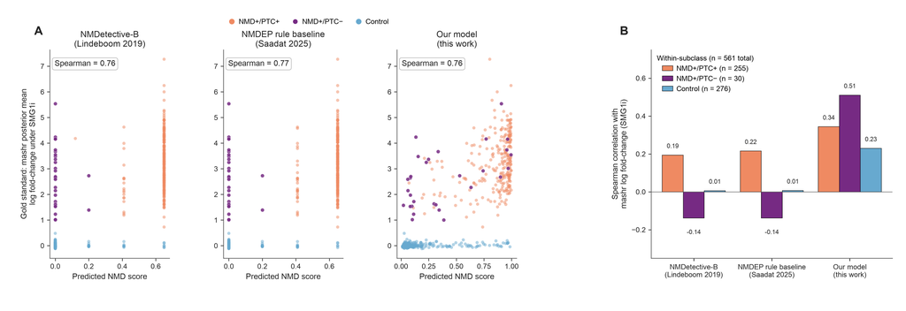

Supplemental Figure S_x — see figures/SupplementalFigures/ModelComparison/figure_s_model_comparison_legend.md for the published legend.

## 7. Take-aways

1. **Pooled performance is uninformative for this comparison.** The pooled Spearman of ≈0.76–0.77 across all three models would suggest equivalent predictive power; the within-subclass breakdown shows this is driven entirely by the (easy) Controls-vs-NMD-substrate separation.
2. **Rule-based predictors fail on PTC-negative NMD substrates.** Both rule cascades classify every NMD+/PTC− isoform as “escape NMD” despite their being real NMD substrates by the mashr gold standard. The resulting Spearman ≈ −0.14 is small in magnitude only because the rule scores cluster on a few discrete leaves; the sign is the meaningful result.
3. **The deep-learning model retains within-subclass discrimination across all three subclasses.** This pattern is consistent with the model learning continuous sequence and structural signal beyond the categorical 50-nt rule.
4. **The NMDetective-B vs NMDEP rule-tree threshold difference is immaterial** at the scale of this cohort (98.9% binary-call agreement). The two rule-based predictors are effectively a single baseline.

## 8. Deferred models

Two model variants were not scored in this comparison because their trained weights / inference code are not publicly available:

- **Full-rank NMDetective-A** (Lindeboom 2019) — the random-forest variant. The associated figshare deposit (10.6084/m9.figshare.7803398) contains only precomputed per-nucleotide NMD scores as GTF files for canonical UCSC knownGene transcripts (hg19 / hg38 / mm9 / mm10), with no model object or inference code released.
- **Full NMDEP MLP** (Saadat & Fellay 2025) — a 60-feature deep model that augments the rule tree with Orthrus pre-trained mRNA sequence embeddings and three internal XGBoost auxiliary regressors (half-life / ribosome loading / localization). No public code, weights, or precomputed predictions located at the time of writing ([arXiv:2502.14547](https://arxiv.org/abs/2502.14547)), and the published input pipeline is variant-centric (VEP-annotated stop-gain variants on a single canonical transcript per gene) rather than designed for arbitrary long-read isoform sequences.

## 9. Reproducibility

All files live under `code/nmd_predictor_comparison/`:

| File | Produced by |
| --- | --- |
| `METHODS.md` | manual (pre-registration) |
| `README.md` | manual |
| `predictions_all_atg500_stop500.tsv` | `explorer_run/run_infer_all.py` (cluster) |
| `isoforms_2026.6.20.tsv` | `01_extract_our_isoforms.R` |
| `nmdetective_b_scores_2026.6.20.tsv` | `02_score_nmdetective_b.R` |
| `nmdep_rule_baseline_scores_2026.6.20.tsv` | `03_score_nmdep_rule_baseline.R` |
| `per_isoform_scores_2026.6.20.tsv` | `04_compute_metrics.R` |
| `metrics_summary_2026.6.20.tsv` | `04_compute_metrics.R` |
| this report (`.Rmd` and rendered `.html`) | `Rscript -e 'rmarkdown::render(...)'` |

Figure + legend: `figures/SupplementalFigures/ModelComparison/figure_s_model_comparison.{py,pdf,png,_legend.md}`.